# F1 vs. F0 cue-weighting in Children

### Model 4: Fixed Effect of F0

```r
m4_fixed_F0 <- glmer(
  data = df_RQ2,
  formula = hgt ~ F1_Regression_Normalized + F0_Regression_Normalized + (1 + F1_Regression_Normalized | CHILD),
  family = binomial(link = "logit"),
  control = glmerControl(optimizer = "bobyqa", optCtrl = list(maxfun = 10000000))
)

saveRDS(m4_fixed_F0, file = "models/m4_fixed_F0_RQ2_prelex.rds")
anova_results_m4 <- anova(m3_random_slope_F1, m4_fixed_F0)
print(anova_results_m4)
```

```
Data: df_RQ2
Models:
m3_random_slope_F1: hgt ~ F1_Regression_Normalized + (1 + F1_Regression_Normalized | CHILD)
m4_fixed_F0: hgt ~ F1_Regression_Normalized + F0_Regression_Normalized + (1 + F1_Regression_Normalized | CHILD)
                   npar    AIC    BIC  logLik deviance  Chisq Df Pr(>Chisq)
m3_random_slope_F1    5 8248.0 8285.5 -4119.0   8238.0
m4_fixed_F0           6 7993.2 8038.1 -3990.6   7981.2 256.86  1  < 2.2e-16 ***
---
Signif. codes:  0 ‘***’ 0.001 ‘**’ 0.01 ‘*’ 0.05 ‘.’ 0.1 ‘ ’ 1
```

➡️ The added predictor F0_Regression_Normalized significantly improves the model fit and was retained for further analysis.

### Model 5: Random Slope for F0

```r
m5_random_slope_F0 <- glmer(
  data = df_RQ2,
  formula = hgt ~ F1_Regression_Normalized + F0_Regression_Normalized + (1 + F1_Regression_Normalized  + F0_Regression_Normalized | CHILD),
  family = binomial(link = "logit"),
  control = glmerControl(optimizer = "bobyqa", optCtrl = list(maxfun = 10000000))
)

save(m5_random_slope_F0, file = "models/m5_random_slope_F0_RQ2_prelex.rds")
anova_results_m5 <- anova(m4_fixed_F0, m5_random_slope_F0)
print(anova_results_m5)
```

```
Data: df_RQ2
Models:
m4_fixed_F0: hgt ~ F1_Regression_Normalized + F0_Regression_Normalized + (1 + F1_Regression_Normalized | CHILD)
m5_random_slope_F0: hgt ~ F1_Regression_Normalized + F0_Regression_Normalized + (1 + F1_Regression_Normalized + F0_Regression_Normalized | CHILD)
                   npar    AIC    BIC  logLik deviance Chisq Df Pr(>Chisq)
m4_fixed_F0           6 7993.2 8038.1 -3990.6   7981.2
m5_random_slope_F0    9 7883.8 7951.1 -3932.9   7865.8 115.4  3  < 2.2e-16 ***
---
Signif. codes:  0 ‘***’ 0.001 ‘**’ 0.01 ‘*’ 0.05 ‘.’ 0.1 ‘ ’ 1
```

➡️ The added random slope for F0_Regression_Normalized significantly improves the model fit and was retained for further analysis.

### Model 6: Fixed effect of CBR

```r
m6_fixed_CBR <- glmer(
  data = df_RQ2,
  formula = hgt ~ F1_Regression_Normalized + F0_Regression_Normalized + CBR + (1 + F1_Regression_Normalized + F0_Regression_Normalized  | CHILD),
  family = binomial(link = "logit"),
  control = glmerControl(optimizer = "bobyqa", optCtrl = list(maxfun = 10000000))
)

saveRDS(m6_fixed_CBR, file = "models/m6_fixed_CBR_RQ2_prelex.rds")
anova_results_m6 <- anova(m5_random_slope_F0, m6_fixed_CBR)
print(anova_results_m6)
```

```
Data: df_RQ2
Models:
m5_random_slope_F0: hgt ~ F1_Regression_Normalized + F0_Regression_Normalized + (1 + F1_Regression_Normalized + F0_Regression_Normalized | CHILD)
m6_fixed_CBR: hgt ~ F1_Regression_Normalized + F0_Regression_Normalized + CBR + (1 + F1_Regression_Normalized + F0_Regression_Normalized | CHILD)
                   npar    AIC    BIC  logLik deviance  Chisq Df Pr(>Chisq)
m5_random_slope_F0    9 7883.8 7951.1 -3932.9   7865.8
m6_fixed_CBR         10 7872.0 7946.9 -3926.0   7852.0 13.753  1  0.0002085 ***
---
Signif. codes:  0 ‘***’ 0.001 ‘**’ 0.01 ‘*’ 0.05 ‘.’ 0.1 ‘ ’ 1
```

➡️ The added predictor CBR significantly improves the model fit and was retained for further analysis.

### Model 7: Random Slope for CBR

```r
m7_random_slope_CBR <- glmer(
  data = df_RQ2,
  formula = hgt ~ F1_Regression_Normalized + F0_Regression_Normalized + CBR + (1 + F1_Regression_Normalized + F0_Regression_Normalized  | CHILD)+(0+CBR|CHILD),
  family = binomial(link = "logit"),
  control = glmerControl(optimizer = "bobyqa", optCtrl = list(maxfun = 10000000))
)

saveRDS(m7_random_slope_CBR, file = "models/m7_random_slope_CBR_RQ2_prelex.rds")
anova_results_m7 <- anova(m6_fixed_CBR, m7_random_slope_CBR)
print(anova_results_m7)
```

```
Data: df_RQ2
Models:
m6_fixed_CBR: hgt ~ F1_Regression_Normalized + F0_Regression_Normalized + CBR + (1 + F1_Regression_Normalized + F0_Regression_Normalized | CHILD)
m7_random_slope_CBR: hgt ~ F1_Regression_Normalized + F0_Regression_Normalized + CBR + (1 + F1_Regression_Normalized + F0_Regression_Normalized | CHILD) + (0 + CBR | CHILD)
                    npar    AIC    BIC  logLik deviance  Chisq Df Pr(>Chisq)
m6_fixed_CBR          10 7872.0 7946.9 -3926.0   7852.0
m7_random_slope_CBR   11 7804.7 7887.0 -3891.3   7782.7 69.333  1  < 2.2e-16 ***
---
Signif. codes:  0 ‘***’ 0.001 ‘**’ 0.01 ‘*’ 0.05 ‘.’ 0.1 ‘ ’ 1
```

➡️ The added random slope for CBR significantly improves the model fit and was retained for further analysis.

### Model 8: Quadratic effect of CBR

```r
m8_quadratic_CBR <- glmer(
  data = df_RQ2,
  formula = hgt ~ F1_Regression_Normalized + F0_Regression_Normalized + CBR + I(CBR^2)   + (1 + F1_Regression_Normalized+F0_Regression_Normalized   | CHILD)+(0+CBR|CHILD),
  family = binomial(link = "logit"),
  control = glmerControl(optimizer = "bobyqa", optCtrl = list(maxfun = 10000000))
)

saveRDS(m8_quadratic_CBR, file = "models/m8_quadratic_CBR_RQ2_prelex.rds")
anova_results_m8 <- anova(m7_random_slope_CBR, m8_quadratic_CBR)
print(anova_results_m8)
```

```
Data: df_RQ2
Models:
m7_random_slope_CBR: hgt ~ F1_Regression_Normalized + F0_Regression_Normalized + CBR + (1 + F1_Regression_Normalized + F0_Regression_Normalized | CHILD) + (0 + CBR | CHILD)
m8_quadratic_CBR: hgt ~ F1_Regression_Normalized + F0_Regression_Normalized + CBR + I(CBR^2) + (1 + F1_Regression_Normalized + F0_Regression_Normalized | CHILD) + (0 + CBR | CHILD)
                    npar    AIC    BIC  logLik deviance  Chisq Df Pr(>Chisq)
m7_random_slope_CBR   11 7804.7 7887.0 -3891.3   7782.7
m8_quadratic_CBR      12 7784.5 7874.3 -3880.2   7760.5 22.227  1  2.422e-06 ***
---
Signif. codes:  0 ‘***’ 0.001 ‘**’ 0.01 ‘*’ 0.05 ‘.’ 0.1 ‘ ’ 1
```

➡️ The added quadratic effect of CBR significantly improves the model fit and was retained for further analysis.

### Model 9: Quadratic slope for CBR

```r
m9_quadratic_slope_CBR <- glmer(
  data = df_RQ2,
  formula = hgt ~ F1_Regression_Normalized + F0_Regression_Normalized + CBR + I(CBR^2)   + (1 + F1_Regression_Normalized+F0_Regression_Normalized   | CHILD)+(0+CBR+ I(CBR^2)|CHILD),
  family = binomial(link = "logit"),
  control = glmerControl(optimizer = "bobyqa", optCtrl = list(maxfun = 10000000))
)

saveRDS(m9_quadratic_slope_CBR, file = "models/m9_quadratic_slope_CBR_RQ2_prelex.rds")
anova_results_m9 <- anova(m8_quadratic_CBR, m9_quadratic_slope_CBR)
print(anova_results_m9)
```

```
Data: df_RQ2
Models:
m8_quadratic_CBR: hgt ~ F1_Regression_Normalized + F0_Regression_Normalized + CBR + I(CBR^2) + (1 + F1_Regression_Normalized + F0_Regression_Normalized | CHILD) + (0 + CBR | CHILD)
m9_quadratic_slope_CBR: hgt ~ F1_Regression_Normalized + F0_Regression_Normalized + CBR + I(CBR^2) + (1 + F1_Regression_Normalized + F0_Regression_Normalized | CHILD) + (0 + CBR + I(CBR^2) | CHILD)
                       npar    AIC    BIC  logLik deviance  Chisq Df Pr(>Chisq)
m8_quadratic_CBR         12 7784.5 7874.3 -3880.2   7760.5
m9_quadratic_slope_CBR   14 7710.2 7815.0 -3841.1   7682.2 78.287  2  < 2.2e-16 ***
---
Signif. codes:  0 ‘***’ 0.001 ‘**’ 0.01 ‘*’ 0.05 ‘.’ 0.1 ‘ ’ 1
```

➡️ The added quadratic slope for CBR significantly improves the model fit and was retained for further analysis.

### Model 10: Cubic effect of CBR

```r
m10_cubic_CBR <- glmer(
  data = df_RQ2,
  formula = hgt ~ F1_Regression_Normalized + F0_Regression_Normalized + CBR + I(CBR^2) + I(CBR^3)  + (1 + F1_Regression_Normalized+F0_Regression_Normalized   | CHILD)+(0+CBR+ I(CBR^2)|CHILD),
  family = binomial(link = "logit"),
  control = glmerControl(optimizer = "bobyqa", optCtrl = list(maxfun = 10000000))
)

saveRDS(m10_cubic_CBR, file = "models/m10_cubic_CBR_RQ2_prelex.rds")
anova_results_m10 <- anova(m9_quadratic_slope_CBR, m10_cubic_CBR)
print(anova_results_m10)
```

```
Data: df_RQ2
Models:
m9_quadratic_slope_CBR: hgt ~ F1_Regression_Normalized + F0_Regression_Normalized + CBR + I(CBR^2) + (1 + F1_Regression_Normalized + F0_Regression_Normalized | CHILD) + (0 + CBR + I(CBR^2) | CHILD)
m10_cubic_CBR: hgt ~ F1_Regression_Normalized + F0_Regression_Normalized + CBR + I(CBR^2) + I(CBR^3) + (1 + F1_Regression_Normalized + F0_Regression_Normalized | CHILD) + (0 + CBR + I(CBR^2) | CHILD)
                       npar    AIC  BIC  logLik deviance  Chisq Df Pr(>Chisq)
m9_quadratic_slope_CBR   14 7710.2 7815 -3841.1   7682.2
m10_cubic_CBR            15 7708.7 7821 -3839.4   7678.7 3.4252  1    0.06421 .
---
Signif. codes:  0 ‘***’ 0.001 ‘**’ 0.01 ‘*’ 0.05 ‘.’ 0.1 ‘ ’ 1
```

### Model 11: Cubic slope for CBR

```r
m11_cubic_slope_CBR <- glmer(
  data = df_RQ2,
  formula = hgt ~ F1_Regression_Normalized + F0_Regression_Normalized + CBR + I(CBR^2) + I(CBR^3)  + (1 + F1_Regression_Normalized+F0_Regression_Normalized   | CHILD)+(0+CBR+ I(CBR^2)+I(CBR^3)|CHILD),
  family = binomial(link = "logit"),
  control = glmerControl(optimizer = "bobyqa", optCtrl = list(maxfun = 10000000))
)

saveRDS(m11_cubic_slope_CBR, file = "models/m11_cubic_slope_CBR_RQ2_prelex.rds")
anova_results_m11 <- anova(m10_cubic_CBR, m11_cubic_slope_CBR)
print(anova_results_m11)
```

```
Data: df_RQ2
Models:
m10_cubic_CBR: hgt ~ F1_Regression_Normalized + F0_Regression_Normalized + CBR + I(CBR^2) + I(CBR^3) + (1 + F1_Regression_Normalized + F0_Regression_Normalized | CHILD) + (0 + CBR + I(CBR^2) | CHILD)
m11_cubic_slope_CBR: hgt ~ F1_Regression_Normalized + F0_Regression_Normalized + CBR + I(CBR^2) + I(CBR^3) + (1 + F1_Regression_Normalized + F0_Regression_Normalized | CHILD) + (0 + CBR + I(CBR^2) + I(CBR^3) | CHILD)
                    npar    AIC    BIC  logLik deviance  Chisq Df Pr(>Chisq)
m10_cubic_CBR         15 7708.7 7821.0 -3839.4   7678.7
m11_cubic_slope_CBR   18 7573.9 7708.6 -3768.9   7537.9 140.88  3  < 2.2e-16 ***
---
Signif. codes:  0 ‘***’ 0.001 ‘**’ 0.01 ‘*’ 0.05 ‘.’ 0.1 ‘ ’ 1
```

➡️ The added cubic slope for CBR significantly improves the model fit and was retained for further analysis.

### Model 12: Interaction between F1 and F0

```r
m12_interaction_F1_F0 <- glmer(
  data = df_RQ2,
  formula = hgt ~ F1_Regression_Normalized + F0_Regression_Normalized + CBR + I(CBR^2) + I(CBR^3) +
    F1_Regression_Normalized : F0_Regression_Normalized + (1 + F1_Regression_Normalized + F0_Regression_Normalized   | CHILD)+(0+CBR+ I(CBR^2)+I(CBR^3)|CHILD),
  family = binomial(link = "logit"),
  control = glmerControl(optimizer = "bobyqa", optCtrl = list(maxfun = 10000000))
)
```

```
boundary (singular) fit: see help('isSingular')
```

```r
saveRDS(m12_interaction_F1_F0, file = "models/m12_interaction_F1_F0_RQ2_prelex.rds")
anova_results_m12 <- anova(m11_cubic_slope_CBR, m12_interaction_F1_F0)
print(anova_results_m12)
```

```
Data: df_RQ2
Models:
m11_cubic_slope_CBR: hgt ~ F1_Regression_Normalized + F0_Regression_Normalized + CBR + I(CBR^2) + I(CBR^3) + (1 + F1_Regression_Normalized + F0_Regression_Normalized | CHILD) + (0 + CBR + I(CBR^2) + I(CBR^3) | CHILD)
m12_interaction_F1_F0: hgt ~ F1_Regression_Normalized + F0_Regression_Normalized + CBR + I(CBR^2) + I(CBR^3) + F1_Regression_Normalized:F0_Regression_Normalized + (1 + F1_Regression_Normalized + F0_Regression_Normalized | CHILD) + (0 + CBR + I(CBR^2) + I(CBR^3) | CHILD)
                      npar    AIC    BIC  logLik deviance Chisq Df Pr(>Chisq)
m11_cubic_slope_CBR     18 7573.9 7708.6 -3768.9   7537.9
m12_interaction_F1_F0   19 7657.2 7799.5 -3809.6   7619.2     0  1          1
```

➡️ The added interaction between F1_Regression_Normalized and F0_Regression_Normalized did not significantly improve the model fit and was not retained for further analysis.

### Model 13: Interaction between F1 and CBR

```r
m13_interaction_F1_CBR <- glmer(
  data = df_RQ2,
  formula = hgt ~ F1_Regression_Normalized + F0_Regression_Normalized + CBR + I(CBR^2) + I(CBR^3) +
    F1_Regression_Normalized : CBR + (1 + F1_Regression_Normalized + F0_Regression_Normalized   | CHILD)+(0+CBR+ I(CBR^2)+I(CBR^3)|CHILD),
  family = binomial(link = "logit"),
  control = glmerControl(optimizer = "bobyqa", optCtrl = list(maxfun = 10000000))
)

saveRDS(m13_interaction_F1_CBR, file = "models/m13_interaction_F1_CBR_RQ2_prelex.rds")
anova_results_m13 <- anova(m11_cubic_slope_CBR, m13_interaction_F1_CBR)
print(anova_results_m13)
```

```
Data: df_RQ2
Models:
m11_cubic_slope_CBR: hgt ~ F1_Regression_Normalized + F0_Regression_Normalized + CBR + I(CBR^2) + I(CBR^3) + (1 + F1_Regression_Normalized + F0_Regression_Normalized | CHILD) + (0 + CBR + I(CBR^2) + I(CBR^3) | CHILD)
m13_interaction_F1_CBR: hgt ~ F1_Regression_Normalized + F0_Regression_Normalized + CBR + I(CBR^2) + I(CBR^3) + F1_Regression_Normalized:CBR + (1 + F1_Regression_Normalized + F0_Regression_Normalized | CHILD) + (0 + CBR + I(CBR^2) + I(CBR^3) | CHILD)
                       npar    AIC    BIC  logLik deviance  Chisq Df Pr(>Chisq)
m11_cubic_slope_CBR      18 7573.9 7708.6 -3768.9   7537.9
m13_interaction_F1_CBR   19 7545.4 7687.7 -3753.7   7507.4 30.434  1  3.454e-08 ***
---
Signif. codes:  0 ‘***’ 0.001 ‘**’ 0.01 ‘*’ 0.05 ‘.’ 0.1 ‘ ’ 1
```

➡️ The added interaction between F1_Regression_Normalized and CBR significantly improves the model fit and was retained for further analysis.

### Model 14: Interaction between F1 and quadratic CBR

```r
m14_interaction_F1_quadratic_CBR <- glmer(
  data = df_RQ2,
  formula = hgt ~ F1_Regression_Normalized + F0_Regression_Normalized + CBR + I(CBR^2) + I(CBR^3) +
    F1_Regression_Normalized : (CBR + I(CBR^2)) + (1 + F1_Regression_Normalized + F0_Regression_Normalized   | CHILD)+(0+CBR+ I(CBR^2)+I(CBR^3)|CHILD),
  family = binomial(link = "logit"),
  control = glmerControl(optimizer = "bobyqa", optCtrl = list(maxfun = 10000000))
)

saveRDS(m14_interaction_F1_quadratic_CBR, file = "models/m14_interaction_F1_quadratic_CBR_RQ2_prelex.rds")
anova_results_m14 <- anova(m13_interaction_F1_CBR, m14_interaction_F1_quadratic_CBR)
print(anova_results_m14)
```

```
Data: df_RQ2
Models:
m13_interaction_F1_CBR: hgt ~ F1_Regression_Normalized + F0_Regression_Normalized + CBR + I(CBR^2) + I(CBR^3) + F1_Regression_Normalized:CBR + (1 + F1_Regression_Normalized + F0_Regression_Normalized | CHILD) + (0 + CBR + I(CBR^2) + I(CBR^3) | CHILD)
m14_interaction_F1_quadratic_CBR: hgt ~ F1_Regression_Normalized + F0_Regression_Normalized + CBR + I(CBR^2) + I(CBR^3) + F1_Regression_Normalized:(CBR + I(CBR^2)) + (1 + F1_Regression_Normalized + F0_Regression_Normalized | CHILD) + (0 + CBR + I(CBR^2) + I(CBR^3) | CHILD)
                                 npar    AIC    BIC  logLik deviance Chisq Df Pr(>Chisq)
m13_interaction_F1_CBR             19 7545.4 7687.7 -3753.7   7507.4
m14_interaction_F1_quadratic_CBR   20 7508.6 7658.4 -3734.3   7468.6 38.78  1  4.743e-10 ***
---
Signif. codes:  0 ‘***’ 0.001 ‘**’ 0.01 ‘*’ 0.05 ‘.’ 0.1 ‘ ’ 1
```

### Model 15: Interaction between F1 and cubic CBR

```r
m15_interaction_F1_cubic_CBR <- glmer(
  data = df_RQ2,
  formula = hgt ~ F1_Regression_Normalized + F0_Regression_Normalized + CBR + I(CBR^2) + I(CBR^3) +
    F1_Regression_Normalized : (CBR + I(CBR^2) + I(CBR^3)) + (1 + F1_Regression_Normalized + F0_Regression_Normalized   | CHILD)+(0+CBR+ I(CBR^2)+I(CBR^3)|CHILD),
  family = binomial(link = "logit"),
  control = glmerControl(optimizer = "bobyqa", optCtrl = list(maxfun = 10000000))
)

saveRDS(m15_interaction_F1_cubic_CBR, file = "models/m15_interaction_F1_cubic_CBR_RQ2_prelex.rds")
anova_results_m15 <- anova(m14_interaction_F1_quadratic_CBR, m15_interaction_F1_cubic_CBR)
print(anova_results_m15)
```

```
Data: df_RQ2
Models:
m14_interaction_F1_quadratic_CBR: hgt ~ F1_Regression_Normalized + F0_Regression_Normalized + CBR + I(CBR^2) + I(CBR^3) + F1_Regression_Normalized:(CBR + I(CBR^2)) + (1 + F1_Regression_Normalized + F0_Regression_Normalized | CHILD) + (0 + CBR + I(CBR^2) + I(CBR^3) | CHILD)
m15_interaction_F1_cubic_CBR: hgt ~ F1_Regression_Normalized + F0_Regression_Normalized + CBR + I(CBR^2) + I(CBR^3) + F1_Regression_Normalized:(CBR + I(CBR^2) + I(CBR^3)) + (1 + F1_Regression_Normalized + F0_Regression_Normalized | CHILD) + (0 + CBR + I(CBR^2) + I(CBR^3) | CHILD)
                                 npar    AIC    BIC  logLik deviance  Chisq Df Pr(>Chisq)
m14_interaction_F1_quadratic_CBR   20 7508.6 7658.4 -3734.3   7468.6
m15_interaction_F1_cubic_CBR       21 7498.5 7655.7 -3728.2   7456.5 12.165  1  0.0004869 ***
---
Signif. codes:  0 ‘***’ 0.001 ‘**’ 0.01 ‘*’ 0.05 ‘.’ 0.1 ‘ ’ 1
```

### Model 16: Interaction between F0 and CBR

```r
m16_interaction_F0_CBR <- glmer(
  data = df_RQ2,
  formula = hgt ~ F1_Regression_Normalized + F0_Regression_Normalized + CBR + I(CBR^2) + I(CBR^3) +
    F1_Regression_Normalized:(CBR + I(CBR^2))+
    F0_Regression_Normalized : CBR + (1 + F1_Regression_Normalized + F0_Regression_Normalized   | CHILD)+(0+CBR+ I(CBR^2)+I(CBR^3)|CHILD),
  family = binomial(link = "logit"),
  control = glmerControl(optimizer = "bobyqa", optCtrl = list(maxfun = 10000000))
)
```

```
boundary (singular) fit: see help('isSingular')
```

```r
saveRDS(m16_interaction_F0_CBR, file = "models/m16_interaction_F0_CBR_RQ2_prelex.rds")
anova_results_m16 <- anova(m14_interaction_F1_quadratic_CBR, m16_interaction_F0_CBR)
print(anova_results_m16)
```

```
Data: df_RQ2
Models:
m14_interaction_F1_quadratic_CBR: hgt ~ F1_Regression_Normalized + F0_Regression_Normalized + CBR + I(CBR^2) + I(CBR^3) + F1_Regression_Normalized:(CBR + I(CBR^2)) + (1 + F1_Regression_Normalized + F0_Regression_Normalized | CHILD) + (0 + CBR + I(CBR^2) + I(CBR^3) | CHILD)
m16_interaction_F0_CBR: hgt ~ F1_Regression_Normalized + F0_Regression_Normalized + CBR + I(CBR^2) + I(CBR^3) + F1_Regression_Normalized:(CBR + I(CBR^2)) + F0_Regression_Normalized:CBR + (1 + F1_Regression_Normalized + F0_Regression_Normalized | CHILD) + (0 + CBR + I(CBR^2) + I(CBR^3) | CHILD)
                                 npar    AIC    BIC  logLik deviance Chisq Df Pr(>Chisq)
m14_interaction_F1_quadratic_CBR   20 7508.6 7658.4 -3734.3   7468.6
m16_interaction_F0_CBR             21 7595.2 7752.5 -3776.6   7553.2     0  1          1
```

➡️ The added interaction between F0_Regression_Normalized and CBR significantly did not improve the model fit and was not retained for further analysis.

# 4. Results Summary 📊

```r
final_model <- m14_interaction_F1_quadratic_CBR
print(summary(final_model))
```

```
Generalized linear mixed model fit by maximum likelihood (Laplace Approximation) ['glmerMod']
 Family: binomial  ( logit )
Formula: hgt ~ F1_Regression_Normalized + F0_Regression_Normalized + CBR +      I(CBR^2) + I(CBR^3) + F1_Regression_Normalized:(CBR + I(CBR^2)) +
    (1 + F1_Regression_Normalized + F0_Regression_Normalized |          CHILD) + (0 + CBR + I(CBR^2) + I(CBR^3) | CHILD)
   Data: df_RQ2
Control: glmerControl(optimizer = "bobyqa", optCtrl = list(maxfun = 1e+07))

     AIC      BIC   logLik deviance df.resid
  7508.6   7658.4  -3734.3   7468.6    13165

Scaled residuals:
    Min      1Q  Median      3Q     Max
-106.97   -0.32   -0.15   -0.04  879.64

Random effects:
 Groups  Name                     Variance  Std.Dev. Corr
 CHILD   (Intercept)                  1.853   1.361
         F1_Regression_Normalized    31.705   5.631   0.36
         F0_Regression_Normalized     7.354   2.712  -0.14 -0.44
 CHILD.1 CBR                        935.455  30.585
         I(CBR^2)                 15480.855 124.422  -0.99
         I(CBR^3)                 16913.493 130.052   0.96 -0.99
Number of obs: 13185, groups:  CHILD, 30

Fixed effects:
                                  Estimate Std. Error z value Pr(>|z|)
(Intercept)                        -3.4945     0.4870  -7.175 7.20e-13 ***
F1_Regression_Normalized           -6.7215     1.3737  -4.893 9.93e-07 ***
F0_Regression_Normalized            3.5022     0.5759   6.081 1.19e-09 ***
CBR                                 7.7519     2.7292   2.840  0.00451 **
I(CBR^2)                          -13.7109     7.6598  -1.790  0.07346 .
I(CBR^3)                           10.5136     7.8991   1.331  0.18319
F1_Regression_Normalized:CBR      -24.3724     4.2396  -5.749 8.99e-09 ***
F1_Regression_Normalized:I(CBR^2)  37.8048     5.0326   7.512 5.82e-14 ***
---
Signif. codes:  0 ‘***’ 0.001 ‘**’ 0.01 ‘*’ 0.05 ‘.’ 0.1 ‘ ’ 1

Correlation of Fixed Effects:
            (Intr) F1_Rg_N F0_R_N CBR    I(CBR^2 I(CBR^3 F1_R_N:C
F1_Rgrssn_N  0.191
F0_Rgrssn_N -0.064 -0.313
CBR         -0.515 -0.050   0.018
I(CBR^2)     0.185  0.033  -0.010 -0.838
I(CBR^3)     0.000 -0.019   0.001  0.500 -0.869
F1_Rg_N:CBR -0.065 -0.576  -0.005  0.084 -0.055   0.028
F1_R_N:I(CB  0.054  0.476   0.007 -0.080  0.055  -0.029  -0.951
```

```r
save.image("/Users/jeremygenette_studio/Documents/Research/Code/IF0_babbling_lexical/image_RQ2_prelex.Rdata")
```

# 5. Plotting the Results 📈

```r
# Define color palettes
F1_color <- c("#8F3400", "#FF681F", "#FFBE8F")
F0_color <- c("#570887", "#A020F0", "#D387F8")

# Define a function for plotting
create_plot <- function(model, term1, term2, colors, y_label, x_label, legend_title) {
  plot <- plot_model(model, type = "pred", terms = c("CBR [all]", term2, term1)
                     , pred.type = "fe",
                     mdrt.values = "meansd"
                     ) +
    labs(
      color = legend_title,
      y = y_label,
      x = x_label,
      title = ""
    ) +
    theme_cowplot() +
    scale_color_manual(values = colors) +
    scale_fill_manual(values = colors) +
    scale_y_continuous(labels = scales::percent_format(), limits = c(0, 1)) +
    theme(legend.position = "bottom", legend.box = "horizontal")
  return(plot)
}

# Ensure the 'graph' folder exists
if (!dir.exists("graph")) dir.create("graph")

# Create and save plots for F1
plot_f1 <- create_plot(
  final_model,
  term1 = "CHILD",
  term2 = "F1_Regression_Normalized",
  colors = F1_color,
  y_label = "Predicted probability of a vowel being high",
  x_label = "CBR",
  legend_title = "Normalized F1"
)
plot_f1
ggsave("graph/RQ2_prelex_plot_F1_child.png", plot_f1, width = 8, height = 8, dpi = 300)
```

[figure not shown]

```r
# Create and save plots for F0
plot_f0 <- create_plot(
  final_model,
  term1 = "CHILD",
  term2 = "F0_Regression_Normalized",
  colors = F0_color,
  y_label = "Predicted probability of a vowel being high",
  x_label = "CBR",
  legend_title = "Normalized F0"
)
ggsave("graph/RQ2_prelex_plot_F0_child.png", plot_f0, width = 8, height = 8, dpi = 300)
```

[figure not shown]

```r
plot_f0
# Create and save plots for F1 without CHILD factor
plot_f1_no_child <- create_plot(
  final_model,
  term1 = NULL,
  term2 = "F1_Regression_Normalized",
  colors = F1_color,
  y_label = "Predicted probability of a vowel being high",
  x_label = "CBR",
  legend_title = "Normalized F1"
)
ggsave("graph/RQ2_prelex_plot_F1.png", plot_f1_no_child, width = 8, height = 6, dpi = 300)
```

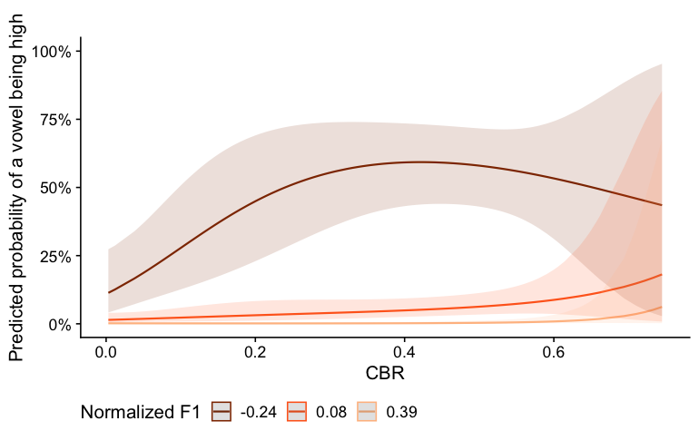

```r
plot_f1_no_child
```

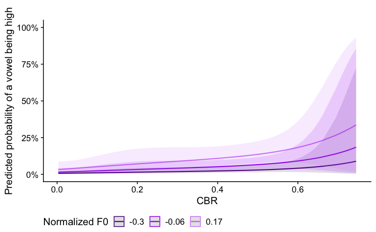

```r
# Create and save plots for F0 without CHILD factor
plot_f0_no_child <- create_plot(
  final_model,
  term1 = NULL,
  term2 = "F0_Regression_Normalized",
  colors = F0_color,
  y_label = "Predicted probability of a vowel being high",
  x_label = "CBR",
  legend_title = "Normalized F0"
)
plot_f0_no_child
ggsave("graph/RQ2_prelex_plot_F0.png", plot_f0_no_child, width = 8, height = 6, dpi = 300)
```